# Week 5 - Homework

Author

David Gonzalez Chavez

# Data

The data for this homework assignment comes from the 2022 GSS.

```r
gss2022 <- gss_get_yr(year = 2022) |> # get 2022 GSS data
  haven::zap_labels()                 # remove labels
```

# Variable #1:

The first variable I am using from the 2022 GSS is the number of hours per day respondents have to relax (hrsrelax). It is a continuous variable.

```r
hrs_data <- gss2022 |>
  select(hrsrelax) |> # select the hrsrelax variable
  drop_na() # drop any rows with N/A values
```

## Histogram

For reference, below is a histogram showing the distribution of “hrsrelax”

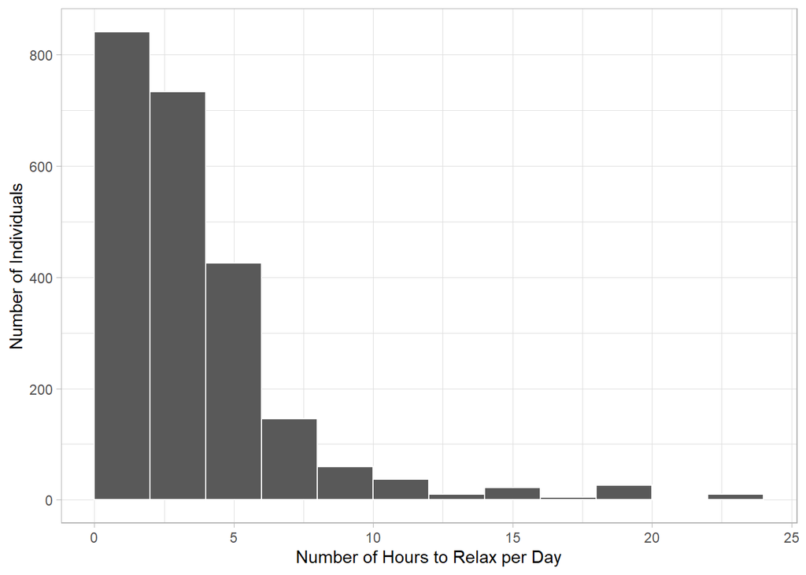

```r
ggplot(hrs_data,
       aes(x = hrsrelax)) +
  geom_histogram(color = "white",
                 binwidth = 2, # set bin width to 2, ensures a reasonable number of bins
                 boundary = 0) +
  xlab("Number of Hours to Relax per Day") +
  ylab("Number of Individuals")
```

## Mean, SD, and Confidence Intervals

```r
ci_89_hrs = qt(p=0.5+(.89/2), df = nrow(hrs_data) - 1) # get the number of SDs above/below to get confidence interval. p is the desired percentile (50% - half of the desired percentile, which I can + or - to the mean to get my desired CI). qt uses nrow to calculate SE.

ci_95_hrs = qt(p=0.5+(.95/2), df = nrow(hrs_data) - 1)

ci_99_hrs = qt(p=0.5+(.99/2), df = nrow(hrs_data) - 1)

mean_hrs = mean(hrs_data$hrsrelax)

sd_hrs = sd(hrs_data$hrsrelax)

se_hrs = sd_hrs / (nrow(hrs_data) ^ .5) # se is sd / sqrt(n)
```

The mean for this variable is 4.11. The standard deviation for this variable is 3.58. An 89% confidence interval is between 3.99 and 4.22. A 95% confidence interval is between 3.96 and 4.25. A 99% confidence interval is between 3.91 and 4.3.

It is not accurate to say that we are 89/95/99% certain that the correct value is in those ranges. Instead, (copied verbatim from slides), “if we did the same study infinite times, [89/95/99]% of the computed intervals would contain the true value.”

# Variable #2:

The first variable I am using from the 2022 GSS is respondent’s confidence in the existence of god (god), which I make binary by setting those who believe with no doubts to 1 and all others to 0 in my constructed variable “confident_believer.”

```r
god_data <- gss2022 |>
  select(god) |> # select the god variable
  drop_na() |> # drop any rows with N/A values
  mutate(confident_believer = if_else(god == 6, 1, 0)) |> # anyone who responded they believe with no doubts is a confident believer, all others are not
  select(confident_believer)
```

## Bar Chart

For reference, below is a histogram showing the distribution of “confident_believer.” Please note it’s almost 50/50.

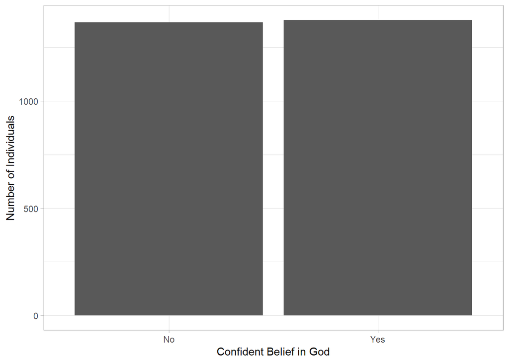

```r
bar_chart_data = god_data |>
  mutate(Is_Confident_Believer = if_else(confident_believer == 1, "Yes", "No"))

ggplot(bar_chart_data,
       aes(x = Is_Confident_Believer)) +
  geom_bar() +
  xlab("Confident Belief in God") +
  ylab("Number of Individuals")
```

## Mean, SD, and Confidence Intervals

```r
mean_god = mean(god_data$confident_believer) # mean for a bernoulli distribution is the probability of 1, which we can just calculate with the mean formula

variance_god = mean_god * (1 - mean_god) # variance is p(1-p)

sd_god = variance_god^(1/2) # sd is sqrt of variance

se_god = sd_god / (nrow(god_data) ^ 0.5)

ci_89_god = qt(p=0.5+(.89/2), df = nrow(god_data) - 1) # get the number of SDs above/below to get confidence interval. p is the desired percentile (50% - half of the desired percentile, which I can + or - to the mean to get my desired CI). qt uses nrow to calculate SE.

ci_95_god = qt(p=0.5+(.95/2), df = nrow(god_data) - 1)

ci_99_god = qt(p=0.5+(.99/2), df = nrow(god_data) - 1)
```

The mean for this variable is 0.5 and the standard deviation for this variable is 0.5. An 89% confidence interval is between 0.49 and 0.52. A 95% confidence interval is between 0.48 and 0.52. A 99% confidence interval is between 0.48 and 0.53.

It is not accurate to say that we are 89/95/99% certain that the correct value is in those ranges. Instead, (copied verbatim from slides), “if we did the same study infinite times, [89/95/99]% of the computed intervals would contain the true value.”

# Simulations

The following simulations demonstrate that simulation-based standard deviations of the estimate converge to the formula based standard error of the sampling distribution.

These simulations will use ~ a 95% confidence interval (2 SDs above and below the mean).

## Binary Variable

The following code creates a population of 100k individuals and assigns 65% of them to the category “dog lover.” It then draws 10,000 samples of size 1,000 each and calculates a ~95.44% confidence interval for each (using standard error, 2 SEs above/below mean) and summarizes the number of samples where the true population parameter (65%) fell within that sample’s confidence interval.

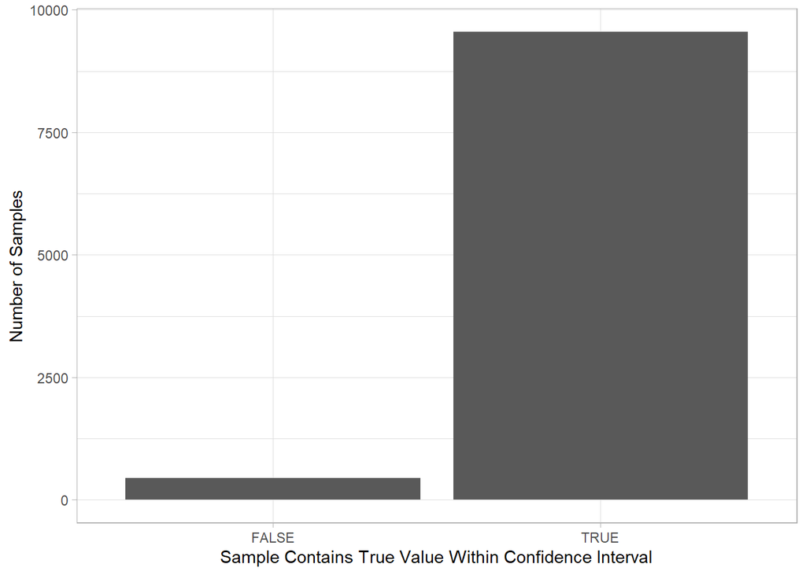

```r
population_dog <- tibble(id = 1:1e5) |> #create table with 100k rows
  mutate(dog_lover = if_else(id<=65000, 1, 0)) |> # first 65k people are dog lovers
  ungroup() # required for some reason

assess_sample_dog <- function(n = 1000) { #default sample size of 1000
  sample = slice_sample(population_dog, n = n) # take a sample from population of size n
  se = sd(sample$dog_lover) / (n^.5) # standard error is sd / sqrt(n)
  between(.65, mean(sample$dog_lover) - (se*2), mean(sample$dog_lover) + (se*2)) # is true value within CI
}

samples_dog <- tibble(id = 1:1e4) |> #run 10k samples
  rowwise() |> # treat each row independently
  mutate(trueValue_within_CI = assess_sample_dog(n=1000)) |> # assess whether the sample's CI had the true mean
  mutate(trueValue_1_0 = if_else(trueValue_within_CI == TRUE, 1, 0))# set to 1 if the true value is in the CI

ggplot(samples_dog,
       aes(x = trueValue_within_CI)) +
  geom_bar() +
  xlab("Sample Contains True Value Within Confidence Interval") +
  ylab("Number of Samples")
```

Overall, 95.51% of the samples had the true mean (65%) within their calculated confidence interval based on 2 standard errors. This is very close to our 95.44% estimate. The idea that we can expect 95.44% of confidence intervals calculated using 2 SEs above and below the mean for different samples will contain the true mean of the population is displayed below using these data:

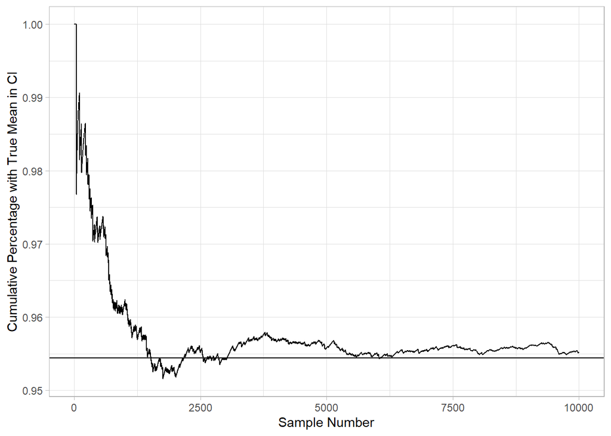

```r
plot_table <- samples_dog |>
  ungroup() |> # required to let me do cumulative mean, had to google this
  mutate(cm = cummean(trueValue_1_0)) # get the cumulative mean, i.e. the cumulative percentage of samples with the true mean in the CI

ggplot(plot_table,
       aes(x = id,
           y = cm)) + # y is the cumulative mean, i.e. what percent of samples at that point had the mean in their CI
  geom_line(color = "black") +
  geom_hline(yintercept = .9544,
             line_type = "dotted") +
  xlab("Sample Number") +
  ylab("Cumulative Percentage with True Mean in CI")
```

## Continuous

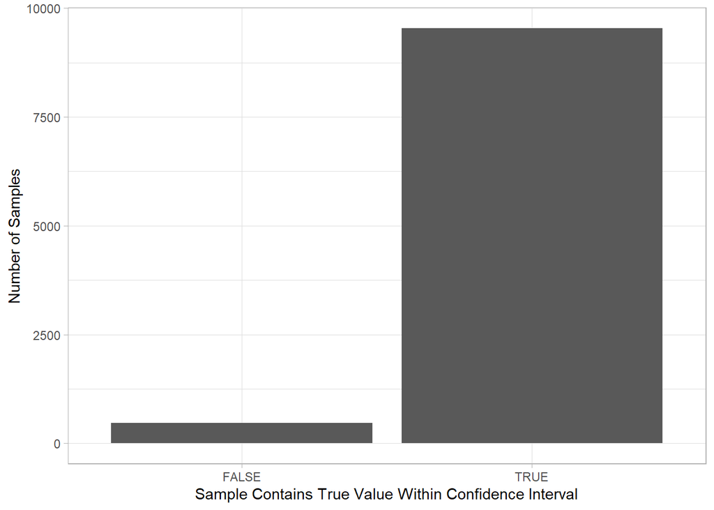

```r
population_age <- tibble(id = 1:1e5) |> #create table with 10k rows
  rowwise() |> # treat each row independently
  mutate(age = runif(1, 0, 100)) |> # random age 1 to 100
  ungroup()

assess_sample_age <- function(n = 1000) { #default sample size of 500
  sample = slice_sample(population_age, n = n) # take a sample from population of size n
  se = sd(sample$age) / (n^.5) # standard error is sd / sqrt(n)
  between(mean(population_age$age), mean(sample$age) - (se*2), mean(sample$age) + (se*2)) # is true value within CI
}

samples_age <- tibble(id = 1:10000) |> #run 10000 samples
  ungroup() |> # required for some reason
  rowwise() |> # treat each row independently
  mutate(trueValue_within_CI = assess_sample_age(n=1000)) |> # assess whether the sample's CI had the true mean
  mutate(trueValue_1_0 = if_else(trueValue_within_CI == TRUE, 1, 0))# set to 1 if the true value is in the CI

ggplot(samples_age,
       aes(x = trueValue_within_CI)) +
  geom_bar() +
  xlab("Sample Contains True Value Within Confidence Interval") +
  ylab("Number of Samples")
```

Overall, 95.36% of the samples had the true mean (50.0419813) within their calculated confidence interval based on 2 standard errors. This is very close to our 95.44% estimate. The idea that we can expect 95.44% of confidence intervals calculated using 2 SEs above and below the mean for different samples will contain the true mean of the population is displayed below using these data:

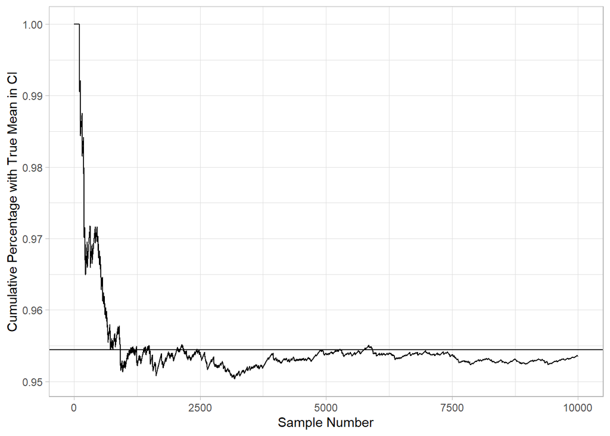

```r
plot_table <- samples_age |>
  ungroup() |> # required to let me do cumulative mean, had to google this
  mutate(cm = cummean(trueValue_1_0)) # get the cumulative mean, i.e. the cumulative percentage of samples with the true mean in the CI

ggplot(plot_table,
       aes(x = id,
           y = cm)) + # y is the cumulative mean, i.e. what percent of samples at that point had the mean in their CI
  geom_line(color = "black") +
  geom_hline(yintercept = .9544,
             line_type = "dotted") +
  xlab("Sample Number") +
  ylab("Cumulative Percentage with True Mean in CI")
```